# 02-01. 데이터 전처리

### 일반화 : 모형이 처음 보는 데이터에 대해 정확하게 예측

### 과대적합 : 정보를 모두 사용해서, 너무 복잡한 모델을 만드는 것

### 과소적합 : 너무 간단한 모델

### 실습 데이터 셋

```python
import pandas as pd
import numpy as np
import sklearn
import matplotlib.pyplot as plt
import mglearn

import warnings
warnings.filterwarnings(action='ignore')
```

- **복수변수 데이터**

```python
x, y = mglearn.datasets.make_forge()
x.shape, y.shape
```

```
((26, 2), (26,))
```

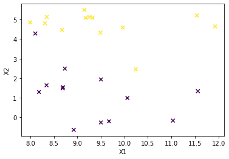

```python
plt.scatter(x[:, 0], x[:, 1], c = y, marker = 'x')
plt.xlabel("X1")
plt.ylabel("X2")
plt.show()
```

- **1변수 데이터**

```python
x, y = mglearn.datasets.make_wave(40)
x.shape, y.shape
```

```
((40, 1), (40,))
```

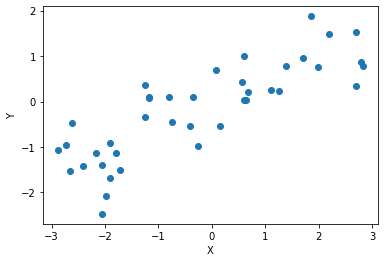

```python
plt.scatter(x, y)
plt.xlabel("X")
plt.ylabel("Y")
plt.show()
```

### **데이터 로드**

```python
heart = pd.read_csv("C:/Soongsil/4-2학기/데이터 마이닝/데마 조별/heart.csv")
heart.shape
```

```
(918, 12)
```

```python
heart.dropna()
np.sum(pd.isnull(heart))
```

```
Age               0
Sex               0
ChestPainType     0
RestingBP         0
Cholesterol       0
FastingBS         0
RestingECG        0
MaxHR             0
ExerciseAngina    0
Oldpeak           0
ST_Slope          0
HeartDisease      0
dtype: int64
```

```python
heart.columns, heart.shape
```

```
(Index(['Age', 'Sex', 'ChestPainType', 'RestingBP', 'Cholesterol', 'FastingBS',
        'RestingECG', 'MaxHR', 'ExerciseAngina', 'Oldpeak', 'ST_Slope',
        'HeartDisease'],
       dtype='object'),
 (918, 12))
```

### scikit-learn 객체에 데이터를 적합하기 위한 차원 조정

### `.reshape(-1, 1)`

```python
heart.Age.shape
```

```
(918,)
```

```python
Age = np.array(heart.Age)
Age.shape
```

```
(918,)
```

```python
Age_reshape = Age.reshape(-1, 1)
Age_reshape.shape
```

```
(918, 1)
```

## 데이터 전처리, 스케일 조정

### 지도학습에서 테스트 데이터를 사용하려면, 훈련 데이터와 테스트 데이터에 같은 변환을 적용

- 예 ${{X_{test}-X_{train\_min}} \over {X_{train\_max}-X_{train\_min}}}$

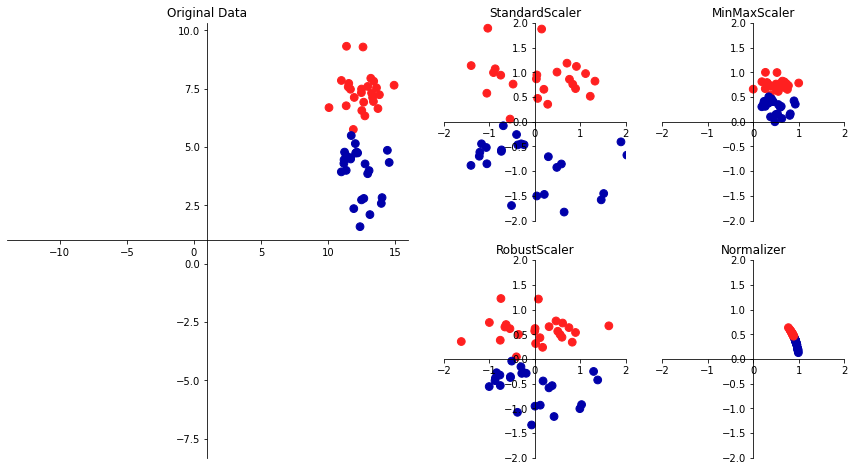

```python
mglearn.plots.plot_scaling()
```

1. `Scaler()` 객체 생성
2. 객체.`fit(df)` 데이터 적용
3. 객체.`transform(df)` : 데이터 변환

### 표준화

### `sklearn.preprocessing.StandardScaler`

- 각 변수의 평균을 0, 분산을 1로 변경하여, 모든 변수가 같은 크기를 가지게 함
- 각 변수의 최솟값과 최댓값 크기를 제한하지 않음

$ x_i^{'} = {{x - \bar{x}} \over {\sigma}} $

```python
from sklearn.preprocessing import StandardScaler
```

```python
x_train, x_test, y_train, y_test = train_test_split(breast.data, breast.target,
                                                    train_size = 0.7)
```

```python
scaler = StandardScaler()
scaler.fit(x_train)
```

```
StandardScaler()
```

```python
x_train_scaled = scaler.transform(x_train)
x_test_scaled = scaler.transform(x_test)
```

### 정규화

### `sklearn.preprocessing.MinMaxScaler`

- 모든 설명변수가 정확하게 0과 1사이에 위치

$ x_i^{'} = \frac{x_i-min(x)}{max(x)-min(x)} $

```python
from sklearn.preprocessing import MinMaxScaler
from sklearn.datasets import load_breast_cancer
from sklearn.model_selection import train_test_split
```

```python
breast = load_breast_cancer()
x_train, x_test, y_train, y_test = train_test_split(breast.data, breast.target,
                                                    train_size=0.7)
```

```python
scaler = MinMaxScaler()
scaler.fit(x_train)
x_train_scaled = scaler.transform(x_train)
x_test_scaled = scaler.transform(x_test)
```

### 로버스트 변환 (RobustScaler)

### `sklearn.preprocessing.RobustScaler`

- 이상치에 영향을 받지 않음

$x_i^{'} = {{x - q_i} \over {q_3 - q_1}} $

- $q_2$ : 중간값, 제 2사분위수 / $q_1$ : 제 1사분위수 / $q_3$ : 제 3분위수

```python
from sklearn.preprocessing import RobustScaler
```

```python
breast = load_breast_cancer()
x_train, x_test, y_train, y_test = train_test_split(breast.data, breast.target,
                                                    train_size=0.7)
```

```python
scaler = RobustScaler()
scaler.fit(x_train)
```

```
RobustScaler()
```

```python
x_train_scaled = scaler.transform(x_train)
x_test_scaled = scaler.transform(x_test)
```

### normalizer

### `sklearn.preprocessing.Normalizer(norm)`

```python
from sklearn.preprocessing import Normalizer
```

```python
x_train_scaled = Normalizer(norm = 'l2').fit_transform(x_train)
x_test_scaled = Normalizer(norm = 'l2').fit_transform(x_test)
```

### 1000개의 분위를 사용하여 데이터를 균등하게 분포

### `sklearn.preprocessing.QuantileTransformer`

- 이상치에 민감하지 않으며, 전체 데이터를 0과 사이로 압축
- `n_quantiles`, `n_features`를 통해분위 값 조절
- `output_distribution` : 'normal'로 지정시 정규분포로 출력 변경 (기본값은 'uniform')

### 데이터의 변수별로 정규분포 형태에 가깝도록 변환

### `sklearn.preprocessing.PowerTransformer`

- `method` : 'yeo-johnson', 'box-cox' : 데이터 정규화

### **범주형 변수 가변수화**

### `pd.get_dummies(df)`

```python
df1 = pd.get_dummies(heart)
```

```python
df1.columns, df1.shape
```

```
(Index(['Age', 'RestingBP', 'Cholesterol', 'FastingBS', 'MaxHR', 'Oldpeak',
        'HeartDisease', 'Sex_F', 'Sex_M', 'ChestPainType_ASY',
        'ChestPainType_ATA', 'ChestPainType_NAP', 'ChestPainType_TA',
        'RestingECG_LVH', 'RestingECG_Normal', 'RestingECG_ST',
        'ExerciseAngina_N', 'ExerciseAngina_Y', 'ST_Slope_Down',
        'ST_Slope_Flat', 'ST_Slope_Up'],
       dtype='object'),
 (918, 21))
```

### 숫자로 표현된 범주형 특성

```python
demo_df = pd.DataFrame({'수치형 변수' : [0, 1, 2, 1],
                        '범주형 변수' : ['양말', '여우', '양말', '상자']})
```

```python
demo_df['수치형 변수'] = demo_df['수치형 변수'].astype(str)
```

```python
pd.get_dummies(demo_df)
```

|  | 수치형 변수_0 | 수치형 변수_1 | 수치형 변수_2 | 범주형 변수_상자 | 범주형 변수_양말 | 범주형 변수_여우 |
| --- | --- | --- | --- | --- | --- | --- |
| 0 | 1 | 0 | 0 | 0 | 1 | 0 |
| 1 | 0 | 1 | 0 | 0 | 0 | 1 |
| 2 | 0 | 0 | 1 | 0 | 1 | 0 |
| 3 | 0 | 1 | 0 | 1 | 0 | 0 |

### **범주형 변수 원-핫 인코딩**

### `sklearn.preprocessing.OneHotEncoder`

1. 원-핫 인코딩 객체 생성 `OneHotEncoder(sparse = False)`
   - spars를 Fasle로 주지 않으면 희소행렬로 반환
2. `fit()` : 어떻게 변환할 것인지에 대해 학습
3. `transform()` : 문자열을 숫자로 변환
4. `fit_transform()` : 학습과 변환을 한 번에 처리
5. `get_feature_names()` : 원-핫 인코딩으로 변환된 열의 이름을 변환 #

#### OneHotEncoder는 모든 변수를 범주형이라고 가정

```python
from sklearn.preprocessing import OneHotEncoder
```

```python
ohe = OneHotEncoder(sparse= False)
```

```python
ohe.fit_transform(demo_df)
```

```
array([[1., 0., 0., 0., 1., 0.],
       [0., 1., 0., 0., 0., 1.],
       [0., 0., 1., 0., 1., 0.],
       [0., 1., 0., 1., 0., 0.]])
```

```python
ohe.get_feature_names()
```

```
array(['x0_0', 'x0_1', 'x0_2', 'x1_상자', 'x1_양말', 'x1_여우'], dtype=object)
```

### 변수마다 다른 변환 적용

### `sklearn.compose.ColumnTransformer`

```python
from sklearn.compose import ColumnTransformer
```

```python
target = heart.HeartDisease
feature = heart.drop("HeartDisease", axis = 1)
```

```python
feature.columns, feature.shape
```

```
(Index(['Age', 'Sex', 'ChestPainType', 'RestingBP', 'Cholesterol', 'FastingBS',
        'RestingECG', 'MaxHR', 'ExerciseAngina', 'Oldpeak', 'ST_Slope'],
       dtype='object'),
 (918, 11))
```

```python
feature.head(2)
```

|  | Age | Sex | ChestPainType | RestingBP | Cholesterol | FastingBS | RestingECG | MaxHR | ExerciseAngina | Oldpeak | ST_Slope |
| --- | --- | --- | --- | --- | --- | --- | --- | --- | --- | --- | --- |
| 0 | 40 | M | ATA | 140 | 289 | 0 | Normal | 172 | N | 0.0 | Up |
| 1 | 49 | F | NAP | 160 | 180 | 0 | Normal | 156 | N | 1.0 | Flat |

```python
ct = ColumnTransformer(
    [("scaling", StandardScaler(), ['Age', 'RestingBP', 'Cholesterol', 'FastingBS', 'MaxHR', 'Oldpeak']),
     ("onehot", OneHotEncoder(sparse = False), ['Sex', 'ChestPainType', 'RestingECG', 'ExerciseAngina', 'ST_Slope'])
    ]
)
```

```python
from sklearn.linear_model import LinearRegression
from sklearn.model_selection import train_test_split
```

```python
x_train, x_test, y_train, y_test = train_test_split(feature, target,
                                                    train_size=0.7, random_state=0)
```

```python
ct.fit(x_train)
x_train_trans = ct.transform(x_train)
x_train_trans.shape
```

```
(642, 20)
```

### `sklearn.compose.make_column_transformer`

- `ColumnTransformer()`를 간편히 실행

```python
from sklearn.compose import make_column_transformer
```

```python
ct = make_column_transformer(
    (StandardScaler(), ['Age', 'RestingBP', 'Cholesterol', 'FastingBS', 'MaxHR', 'Oldpeak']),
    (OneHotEncoder(sparse = False), ['Sex', 'ChestPainType', 'RestingECG', 'ExerciseAngina', 'ST_Slope'])
)
```

```python
x_train_trans = ct.fit_transform(x_train)
x_train_trans.shape
```

```
(642, 20)
```

### 구간 분할 : 한 변수를 여러 변수로 나눔

### `sklearn.preprocessing.KBinsDiscretizer(n_bins, strategy)`

- **변수를 n_bins만큼의 구간 수로**
- 일부 설명변수와 반응변수가 비선형 관계이지만, 용량이 매우 크고 고차원 데이터셋이라 선형 모형을 사용해야 한다면, 구간 분할이 성능에 좋은 방법

```python
from sklearn.preprocessing import KBinsDiscretizer
```

- 변수를 균등하게 10개의 구간으로 분할

```python
kb = KBinsDiscretizer(n_bins = 10, strategy = 'uniform')
```

```python
kb.fit(Age_reshape)
```

```
KBinsDiscretizer(n_bins=10, strategy='uniform')
```

- 구간 분할의 경곗값

```python
kb.bin_edges_
```

```
array([array([28. , 32.9, 37.8, 42.7, 47.6, 52.5, 57.4, 62.3, 67.2, 72.1, 77. ])],
      dtype=object)
```

- **transform은 기본적으로 구간에 원-핫 인코딩을 적용**
- 구간마다 하나의 새로운 특성이 생성 => 희소행렬

```python
X_binned = kb.transform(Age_reshape)
```

```python
X_binned.toarray().shape, Age_reshape.shape
```

```
((918, 10), (918, 1))
```

```python
pd.DataFrame(X_binned.toarray()).head(3)
```

|  | 0 | 1 | 2 | 3 | 4 | 5 | 6 | 7 | 8 | 9 |
| --- | --- | --- | --- | --- | --- | --- | --- | --- | --- | --- |
| 0 | 0.0 | 0.0 | 1.0 | 0.0 | 0.0 | 0.0 | 0.0 | 0.0 | 0.0 | 0.0 |
| 1 | 0.0 | 0.0 | 0.0 | 0.0 | 1.0 | 0.0 | 0.0 | 0.0 | 0.0 | 0.0 |
| 2 | 0.0 | 1.0 | 0.0 | 0.0 | 0.0 | 0.0 | 0.0 | 0.0 | 0.0 | 0.0 |

- **`encode = 'onehot-dense'` => 원-핫 인코딩된 밀집배열**

```python
kb = KBinsDiscretizer(n_bins = 10, strategy = 'uniform', encode = 'onehot-dense')
kb.fit(Age_reshape)
```

```
KBinsDiscretizer(encode='onehot-dense', n_bins=10, strategy='uniform')
```

```python
line_binned = kb.transform(Age_reshape)
```

```python
line_binned.shape
```

```
(918, 10)
```

```python
pd.DataFrame(line_binned).head(3)
```

|  | 0 | 1 | 2 | 3 | 4 | 5 | 6 | 7 | 8 | 9 |
| --- | --- | --- | --- | --- | --- | --- | --- | --- | --- | --- |
| 0 | 0.0 | 0.0 | 1.0 | 0.0 | 0.0 | 0.0 | 0.0 | 0.0 | 0.0 | 0.0 |
| 1 | 0.0 | 0.0 | 0.0 | 0.0 | 1.0 | 0.0 | 0.0 | 0.0 | 0.0 | 0.0 |
| 2 | 0.0 | 1.0 | 0.0 | 0.0 | 0.0 | 0.0 | 0.0 | 0.0 | 0.0 | 0.0 |

- **`encode = 'ordinal'` => 10개의 구간 중 어느 구간에 속하는지 (순서형 변수로 변환)**

```python
kb = KBinsDiscretizer(n_bins = 10, strategy = 'uniform', encode = 'ordinal')
```

```python
kb.fit(Age_reshape)
```

```
KBinsDiscretizer(encode='ordinal', n_bins=10, strategy='uniform')
```

```python
ordinal = kb.transform(Age_reshape)
ordinal.shape
```

```
(918, 1)
```

```python
pd.DataFrame(ordinal).head(3)
```

|  | 0 |
| --- | --- |
| 0 | 2.0 |
| 1 | 4.0 |
| 2 | 1.0 |

### 상호작용

### `np.hstack` : 열 (axis = 1)을 따라 배열을 쌓음

- **열 추가**

```python
Age_combined = np.hstack([Age_reshape, X_binned.toarray()])
Age_combined.shape
```

```
(918, 11)
```

```python
pd.DataFrame(Age_combined).head(3)
```

|  | 0 | 1 | 2 | 3 | 4 | 5 | 6 | 7 | 8 | 9 | 10 |
| --- | --- | --- | --- | --- | --- | --- | --- | --- | --- | --- | --- |
| 0 | 40.0 | 0.0 | 0.0 | 1.0 | 0.0 | 0.0 | 0.0 | 0.0 | 0.0 | 0.0 | 0.0 |
| 1 | 49.0 | 0.0 | 0.0 | 0.0 | 0.0 | 1.0 | 0.0 | 0.0 | 0.0 | 0.0 | 0.0 |
| 2 | 37.0 | 0.0 | 1.0 | 0.0 | 0.0 | 0.0 | 0.0 | 0.0 | 0.0 | 0.0 | 0.0 |

- **상호작용 열 추가**

```python
Age_product= np.hstack([X_binned.toarray(), Age_reshape * X_binned.toarray()])
```

```python
Age_product.shape
```

```
(918, 20)
```

```python
pd.DataFrame(Age_product).head(3)
```

|  | 0 | 1 | 2 | 3 | 4 | 5 | 6 | 7 | 8 | 9 | 10 | 11 | 12 | 13 | 14 | 15 | 16 | 17 | 18 | 19 |
| --- | --- | --- | --- | --- | --- | --- | --- | --- | --- | --- | --- | --- | --- | --- | --- | --- | --- | --- | --- | --- |
| 0 | 0.0 | 0.0 | 1.0 | 0.0 | 0.0 | 0.0 | 0.0 | 0.0 | 0.0 | 0.0 | 0.0 | 0.0 | 40.0 | 0.0 | 0.0 | 0.0 | 0.0 | 0.0 | 0.0 | 0.0 |
| 1 | 0.0 | 0.0 | 0.0 | 0.0 | 1.0 | 0.0 | 0.0 | 0.0 | 0.0 | 0.0 | 0.0 | 0.0 | 0.0 | 0.0 | 49.0 | 0.0 | 0.0 | 0.0 | 0.0 | 0.0 |
| 2 | 0.0 | 1.0 | 0.0 | 0.0 | 0.0 | 0.0 | 0.0 | 0.0 | 0.0 | 0.0 | 0.0 | 37.0 | 0.0 | 0.0 | 0.0 | 0.0 | 0.0 | 0.0 | 0.0 | 0.0 |

### 다항식 추가

### `sklearn.preprocessing.PolynominalFeatures(degree, include_bias)`

- `degree` : 다항식의 차수
- `include_bias` : True이면 절편 추가

```python
from sklearn.preprocessing import PolynomialFeatures
```

```python
poly = PolynomialFeatures(degree = 10, include_bias = False)
poly.fit(Age_reshape)
Age_poly = poly.transform(Age_reshape)
```

```python
Age_poly.shape
```

```
(918, 10)
```

```python
pd.DataFrame(Age_poly).head(3)
```

|  | 0 | 1 | 2 | 3 | 4 | 5 | 6 | 7 | 8 | 9 |
| --- | --- | --- | --- | --- | --- | --- | --- | --- | --- | --- |
| 0 | 40.0 | 1600.0 | 64000.0 | 2560000.0 | 102400000.0 | 4.096000e+09 | 1.638400e+11 | 6.553600e+12 | 2.621440e+14 | 1.048576e+16 |
| 1 | 49.0 | 2401.0 | 117649.0 | 5764801.0 | 282475249.0 | 1.384129e+10 | 6.782231e+11 | 3.323293e+13 | 1.628414e+15 | 7.979227e+16 |
| 2 | 37.0 | 1369.0 | 50653.0 | 1874161.0 | 69343957.0 | 2.565726e+09 | 9.493188e+10 | 3.512479e+12 | 1.299617e+14 | 4.808584e+15 |

- **`.poly_get_feature_names_out()` : 각 변수의 차수를 알려줌**

```python
poly.get_feature_names_out()
```

```
array(['x0', 'x0^2', 'x0^3', 'x0^4', 'x0^5', 'x0^6', 'x0^7', 'x0^8',
       'x0^9', 'x0^10'], dtype=object)
```

### 일변량 비선형 변환 (log, exp, sin 변환)

- 트리 기반 모델은 변수의 순서에만 영향을 받지만, 선형모델과 신경망은 각 변수의 스케일과 분포에 밀접히 연관
- 설명변수와 반응변수 사이에 비선형성이 있다면, 선형회귀에서는 모델생성이 어려움
- **log과 exp : 데이터의 스케일을 변형해, 선형모델과 신경망의 성능을 높임**
- 대부분의 모델은 각 변수가 저육분포와 비슷할 때, 최고의 성능을 보임

```python
rnd = np.random.RandomState(0)
X_org = rnd.normal(size=(1000, 3))
w = rnd.normal(size = 3)
```

```python
X = rnd.poisson(10 * np.exp(X_org))
y = np.dot(X_org, w)
X[:10, 0]
```

```
array([ 56,  81,  25,  20,  27,  18,  12,  21, 109,   7])
```

```python
bins = np.bincount(X[:, 0])
bins
```

```
array([28, 38, 68, 48, 61, 59, 45, 56, 37, 40, 35, 34, 36, 26, 23, 26, 27,
       21, 23, 23, 18, 21, 10,  9, 17,  9,  7, 14, 12,  7,  3,  8,  4,  5,
        5,  3,  4,  2,  4,  1,  1,  3,  2,  5,  3,  8,  2,  5,  2,  1,  2,
        3,  3,  2,  2,  3,  3,  0,  1,  2,  1,  0,  0,  3,  1,  0,  0,  0,
        1,  3,  0,  1,  0,  2,  0,  1,  1,  0,  0,  0,  0,  1,  0,  0,  2,
        2,  0,  1,  1,  0,  0,  0,  0,  1,  1,  0,  0,  0,  0,  0,  0,  0,
        1,  0,  0,  0,  0,  0,  1,  1,  0,  0,  1,  0,  0,  0,  0,  0,  0,
        0,  1,  0,  0,  0,  0,  1,  0,  0,  0,  0,  0,  0,  0,  0,  0,  0,
        0,  0,  0,  0,  1], dtype=int64)
```

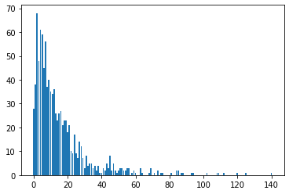

```python
plt.bar(range(len(bins)), bins)
plt.show()
```

### `np.log()` : 로그변환

- 데이터가 0이 있으면, 로그함수 적용 불가 => log(X+1)

```python
X_log = np.log(X+1)
X_log.shape
```

```
(1000, 3)
```

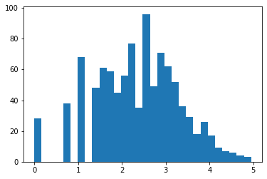

```python
plt.hist(X_log[:, 0], bins = 30)
plt.show()
```

### 설명변수 자동 선택

### 일변량 통계

- 개별 설명변수와, 반응변수 사이에 통계적 관계가 있는지 계산
- **수치형 변수에는 F-검정 / 범주형 변수에는 ANOVA**

### `sklearn.feature_selection.SelectPercentile(score_func, percentile)`

- score_func를 사용하여, 변수의 수를 percintile 만큼을 선택

### `sklearn.feature_selection.f_classif`

- F통계량을 사용

```python
from sklearn.feature_selection import SelectPercentile, f_classif
from sklearn.model_selection import train_test_split
```

```python
breast = load_breast_cancer()
x = breast.data
y = breast.target

x_train, x_test, y_train, y_test = train_test_split(x, y)
```

- **F통계량을 사용하여 설명변수의 50%를 선택**

```python
select = SelectPercentile(score_func = f_classif, percentile = 50)
```

```python
select.fit(x_train, y_train)
```

```
SelectPercentile(percentile=50)
```

```python
x_train_selected = select.transform(x_train)
```

```python
x_train.shape, x_train_selected.shape
```

```
((426, 30), (426, 15))
```

- **`.get_support()` 메서드는 선택된 변수를 boolean값으로 표시, 어떤 변수가 선택되었는지 확인**

```python
mask = select.get_support()
mask
```

```
array([ True, False,  True,  True, False,  True,  True,  True, False,
       False,  True, False,  True,  True, False, False, False, False,
       False, False,  True, False,  True,  True, False,  True,  True,
        True, False, False])
```

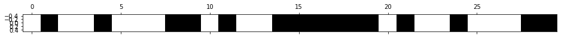

```python
plt.matshow(mask.reshape(1, -1), cmap = 'gray')
plt.show()
```

### 모형 기반 변수 선택

- 트리 기반 모델은, 각 변수의 중요도가 담겨있는 feature*importance* 속성을 제공
- 선형 모형의 계수의 절댓값도 변수의 중요도를 의미
- **모형 기반 변수 선택은, 한 번에 모든 변수를 고려함으로, 상호작용 부분을 반영 가능**

### `sklearn.feature_selection.SelectFromModel(모형, threshold)`

- `SelectFromModel`은 중요도가 지정한 threshold보다 큰 모든 변수를 선택
- `모형` : 변수 선택에 적용할 모형
- `threshold` : 임곗값, ('median', 'mean' 등)

```python
from sklearn.feature_selection import SelectFromModel
from sklearn.ensemble import RandomForestClassifier
```

```python
select = SelectFromModel(
    RandomForestClassifier(n_estimators = 100, random_state = 42),
    threshold = 'median'
)
```

```python
select.fit(x_train, y_train)
x_train_l1 = select.transform(x_train)
```

```python
x_train.shape, x_train_l1.shape
```

```
((426, 30), (426, 15))
```

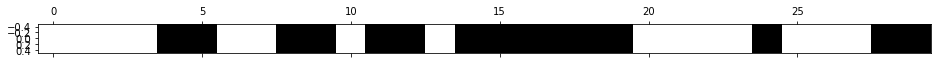

```python
mask = select.get_support()
mask
plt.matshow(mask.reshape(1, -1), cmap = 'gray')
plt.show()
```

### 반복적 변수 선택

- 전진선택법
- 후진선택법 (재귀적 변수 제거, RFE)

### `sklearn.feature_selection.RFE(모형, n_features_to_select)`

- `n_features_to_select` : 선택할 변수의 수

```python
from sklearn.feature_selection import RFE
```

```python
select = RFE(RandomForestClassifier(n_estimators=100, random_state=42),
             n_features_to_select=20)
```

```python
select.fit(x_train, y_train)
```

```
RFE(estimator=RandomForestClassifier(random_state=42), n_features_to_select=20)
```

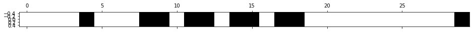

```python
mask = select.get_support()
mask
plt.matshow(mask.reshape(1, -1), cmap = 'gray')
plt.show()
```

### 시계열

```python
import mglearn
```

```python
bike = mglearn.datasets.load_citibike()
```

```python
bike.head(2)
```

```
starttime
2015-08-01 00:00:00    3
2015-08-01 03:00:00    0
Freq: 3H, Name: one, dtype: int64
```

```python
xticks = pd.date_range(start = bike.index.min(),
                       end = bike.index.max(), freq = 'D')
week = ["Mon", "Tue", "Wed", "Thr", "Fri", "Sat", "Sun"]
xticks_name = [week[int(w)]+d for w, d in zip(xticks.strftime("%w"),
                                               xticks.strftime("%m-%d"))]
```

```python
xticks.strftime('%w'), xticks.strftime("%m-%d")
```

```
(Index(['6', '0', '1', '2', '3', '4', '5', '6', '0', '1', '2', '3', '4', '5',
        '6', '0', '1', '2', '3', '4', '5', '6', '0', '1', '2', '3', '4', '5',
        '6', '0', '1'],
       dtype='object'),
 Index(['08-01', '08-02', '08-03', '08-04', '08-05', '08-06', '08-07', '08-08',
        '08-09', '08-10', '08-11', '08-12', '08-13', '08-14', '08-15', '08-16',
        '08-17', '08-18', '08-19', '08-20', '08-21', '08-22', '08-23', '08-24',
        '08-25', '08-26', '08-27', '08-28', '08-29', '08-30', '08-31'],
       dtype='object'))
```

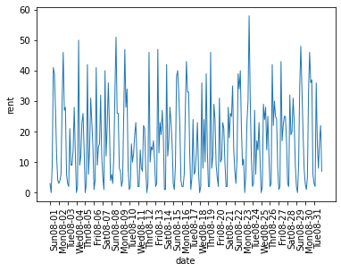

```python
plt.xticks(xticks, xticks_name, rotation = 90, ha = "left")
plt.plot(bike, linewidth = 1)
plt.xlabel("date")
plt.ylabel('rent')
plt.show()
```

```python
y = bike.values
x = bike.index.astype("int64").values.reshape(-1, 1) // 10**9
# DatetimeIndex의 기본 잔위는 나노초 (10^-9)
```

- 처음 184개 데이터를 훈련으로, 나머지는 테스트

```python
n_train = 184
```

```python
def eval_on_feature(features, target, regressor) :
    x_train, x_test = features[:n_train], features[n_train:]
    y_train, y_test= target[:n_train], target[n_train:]
    regressor.fit(x_train, y_train)
    print("R^2 : {:.2f}".format(regressor.score(x_test, y_test)))

    y_pred = regressor.predict(x_test)
    y_pred_train = regressor.predict(x_train)

    plt.figure(figsize = (10, 3))
    plt.xticks(range(0, len(x), 8), xticks_name, rotation = 90, ha = "left")

    plt.plot(range(n_train), y_train, label = "train")
    plt.plot(range(n_train, len(y_test) + n_train), y_test, '-', label = 'test')
    plt.plot(range(n_train), y_pred_train, '--', label = 'train_predict')

    plt.plot(range(n_train, len(y_test) + n_train), y_pred, '--',
             label = 'test_predict')
    plt.legend(loc = (1.01, 0))
    plt.xlabel('date')
    plt.ylabel('rent')
```

```python
from sklearn.ensemble import RandomForestRegressor
```

```
R^2 : -0.04
```

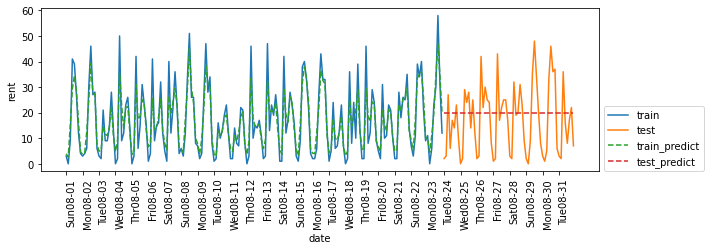

```python
regressor = RandomForestRegressor(n_estimators=100, random_state = 0)
eval_on_feature(x, y , regressor)
```

- **R^2값이 -0.04로 아주 나쁨. Why?**
- 테스트 데이터의 POSIX 시간 변수의 값은, 훈련 데이터에 있는 시간 변수의 범위 밖에 있음 => 테스트 데이터에 있는 데이터는, 훈련 데이터보다 뒤의 시간
- 랜덤 포레스트는 훈련 데이터 시간 변수의 범위 밖으로 **외삽**할 수 있는 기능이 없음

#### => 시간 변수의 시간 단위로 분할하여 변수를 생성

```python
x_hour = bike.index.hour.values.reshape(-1, 1) # 시 (hour) 변수
x_dayofweek = bike.index.dayofweek.values.reshape(-1, 1) # 요일 (dayofweek) 변수
```

```python
x_hour_dayofweek = np.hstack([x_hour, x_dayofweek])
```

```
R^2 : 0.84
```

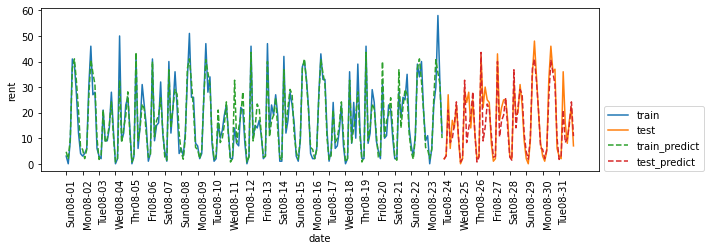

```python
eval_on_feature(x_hour_dayofweek, y, regressor)
```

- **성능이 향상됨**

```python
from sklearn.linear_model import LinearRegression
```

```
R^2 : 0.13
```

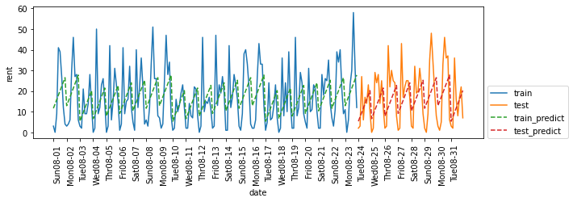

```python
eval_on_feature(x_hour_dayofweek, y, LinearRegression())
```

- **R^2이 0.13으로 성능이 나쁨. Why?**
- 요일과 시간이 정수로 인코딩 => 수치형 변수로 해석됨 => 선형모형은 시간을 선형함수로만 학습 => 하루에서 시간이 흐를수록 대여 수가 증가 => **이를 방지하기 위해 OneHotEncoder 사용하여 범주형 변수로 변환**

```python
enc = OneHotEncoder()
x_hour_week_onehot = enc.fit_transform(x_hour_dayofweek).toarray()
```

```python
x_hour_dayofweek.shape
```

```
(248, 2)
```

```python
x_hour_week_onehot.shape
```

```
(248, 15)
```

```
R^2 : 0.61
```

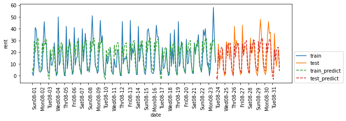

```python
eval_on_feature(x_hour_week_onehot, y, LinearRegression())
```

- **성능 향상됨**
- **상호작용 변수를 사용하면, 시간과 요일의 조합별 계수 학습 가능**

```python
from sklearn.preprocessing import PolynomialFeatures
```

```python
poly_transformer = PolynomialFeatures(degree=2, interaction_only = True,
                                      include_bias=False)
```

```python
x_hour_week_onehot_poly = poly_transformer.fit_transform(x_hour_week_onehot)
x_hour_week_onehot_poly.shape
```

```
(248, 120)
```

```python
lr = LinearRegression()
```

```
R^2 : 0.84
```

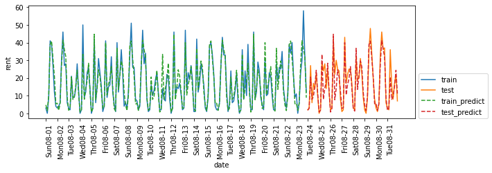

```python
eval_on_feature(x_hour_week_onehot_poly, y, lr)
```

```python
hour = ["%02d:00" % i for i in range(0, 24, 3)]
weekdays = ["Mon", "Tue", "Wed", "Thr", "Fri", "Sat", "Sun"]
features = hour + weekdays
hour, weekdays, features
```

```
(['00:00', '03:00', '06:00', '09:00', '12:00', '15:00', '18:00', '21:00'],
 ['Mon', 'Tue', 'Wed', 'Thr', 'Fri', 'Sat', 'Sun'],
 ['00:00',
  '03:00',
  '06:00',
  '09:00',
  '12:00',
  '15:00',
  '18:00',
  '21:00',
  'Mon',
  'Tue',
  'Wed',
  'Thr',
  'Fri',
  'Sat',
  'Sun'])
```

- **모든 변수들의 이름을 변경**

```python
features_poly = poly_transformer.get_feature_names_out(features)
```

- **회귀계수가 0이 아닌 변수들만 선택**

```python
features_nonzero = np.array(features_poly)[lr.coef_ != 0]
```

```python
coef_nonzero = lr.coef_[lr.coef_ != 0]
```

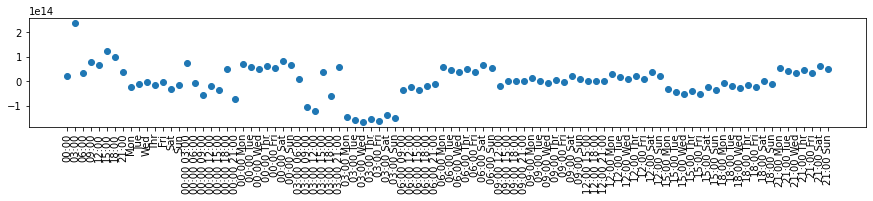

```python
plt.figure(figsize = (15, 2))
plt.plot(coef_nonzero, 'o')
plt.xticks(np.arange(len(coef_nonzero)), features_nonzero, rotation = 90)
plt.show()
```